# Axis Insurance

## BUSINESS OVERVIEW

```
 The Executive management of AXIS Insurance requires expert advise and recommedations from a professsional Data Analyst derived from a healthy extraction of key insights from available data in order to steer a possible product launch as well as design decision and policy formulation initiatives vis-a -vis subscription patterns as a stimulant to gain an apparent competitive edge.
```

## OBJECTIVE – Statistical Analysis of Business Data.

```
1.Explore the dataset and extract insights using Exploratory Data Analysis.

2.Prove (or disprove) that the medical claims made by the people who smoke is greater than those who don't? [Hint- Formulate a hypothesis and prove/disprove it]

3.Prove (or disprove) with statistical evidence that the BMI of females is different from that of males.

4.Is the proportion of smokers significantly different across different regions? [Hint : Create a contingency table/cross tab, Use the function : stats.chi2_contingency()]

5.Is the mean BMI of women with no children, one child, and two children the same? Explain your answer with statistical evidence.
```

- Given: Level of Significance : 0.05 for all tests.

## DATA DICTIONARY

```
Age - This is an integer indicating the age of the primary beneficiary (excluding those above 64 years, since they are generally covered by the government).

Sex - This is the policy holder's gender, either male or female.

BMI - This is the body mass index (BMI), which provides a sense of how over or underweight a person is relative to their height. BMI is equal to weight (in kilograms) divided by height (in meters) squared. An ideal BMI is within the range of 18.5 to 24.9.

Children - This is an integer indicating the number of children/dependents covered by the insurance plan.

Smoker - This is yes or no depending on whether the insured regularly smokes tobacco.

Region - This is the beneficiary's place of residence in the U.S., divided into four geographic regions - northeast, southeast, southwest, or northwest.

Charges - Individual medical costs billed to health insurance
```

### Installing Latest Version of Scipy in the system

```python
!pip install scipy==1.6.1
```

[output not shown]

```python
import scipy
scipy.__version__
```

```
'1.6.1'
```

#### Import the applicable libraries

```python
import pandas as pd # package for data manipulation and analysis
import numpy as np # package for working with arrays
import seaborn as sns # package for data exploration and visualisation
import matplotlib.pyplot as plt # package for plots
%matplotlib inline
import scipy.stats as stats # package for statistical calculations and probability distributions
import warnings
warnings.filterwarnings('ignore')
```

### Reading the Dataset

```python
Axis_Ins = pd.read_csv('AxisInsurance.csv')
```

### Reading the first 5 Entries of the dataset

```python
Axis_Ins.head()
```

|  | age | sex | bmi | children | smoker | region | charges |
| --- | --- | --- | --- | --- | --- | --- | --- |
| 0 | 19 | female | 27.900 | 0 | yes | southwest | 16884.92400 |
| 1 | 18 | male | 33.770 | 1 | no | southeast | 1725.55230 |
| 2 | 28 | male | 33.000 | 3 | no | southeast | 4449.46200 |
| 3 | 33 | male | 22.705 | 0 | no | northwest | 21984.47061 |
| 4 | 32 | male | 28.880 | 0 | no | northwest | 3866.85520 |

### Reading the last 5 Entries of the dataset

```python
Axis_Ins.tail()
```

|  | age | sex | bmi | children | smoker | region | charges |
| --- | --- | --- | --- | --- | --- | --- | --- |
| 1333 | 50 | male | 30.97 | 3 | no | northwest | 10600.5483 |
| 1334 | 18 | female | 31.92 | 0 | no | northeast | 2205.9808 |
| 1335 | 18 | female | 36.85 | 0 | no | southeast | 1629.8335 |
| 1336 | 21 | female | 25.80 | 0 | no | southwest | 2007.9450 |
| 1337 | 61 | female | 29.07 | 0 | yes | northwest | 29141.3603 |

```python
Axis_Ins.sample(15) # To study for data consistency and pick a pattern in a Random number of samples
```

|  | age | sex | bmi | children | smoker | region | charges |
| --- | --- | --- | --- | --- | --- | --- | --- |
| 846 | 51 | female | 34.200 | 1 | no | southwest | 9872.70100 |
| 661 | 57 | female | 23.980 | 1 | no | southeast | 22192.43711 |
| 1310 | 42 | male | 26.315 | 1 | no | northwest | 6940.90985 |
| 1114 | 23 | male | 24.510 | 0 | no | northeast | 2396.09590 |
| 1318 | 35 | male | 39.710 | 4 | no | northeast | 19496.71917 |
| 1326 | 42 | female | 32.870 | 0 | no | northeast | 7050.02130 |
| 762 | 33 | male | 27.100 | 1 | yes | southwest | 19040.87600 |
| 70 | 27 | female | 24.750 | 0 | yes | southeast | 16577.77950 |
| 283 | 55 | female | 32.395 | 1 | no | northeast | 11879.10405 |
| 956 | 54 | male | 30.800 | 1 | yes | southeast | 41999.52000 |
| 1103 | 58 | male | 36.080 | 0 | no | southeast | 11363.28320 |
| 151 | 48 | male | 29.700 | 0 | no | southeast | 7789.63500 |
| 1327 | 51 | male | 30.030 | 1 | no | southeast | 9377.90470 |
| 941 | 50 | female | 46.090 | 1 | no | southeast | 9549.56510 |
| 595 | 46 | female | 33.725 | 1 | no | northeast | 8823.98575 |

#### Observation

##### The dataset indicates a structured set alligning with the description in the Data frame

### Checking the shape of the Dataset

```python
Axis_Ins.shape
```

```
(1338, 7)
```

##### The dataset has 1338 Rows and 7 Columns

### Identifying the Columns of the dataset

```python
Axis_Ins.columns # this indicates the clumns of the dataset
```

```
Index(['age', 'sex', 'bmi', 'children', 'smoker', 'region', 'charges'], dtype='object')
```

### Checking the Data Types

```python
Axis_Ins.info()
```

```
<class 'pandas.core.frame.DataFrame'>
RangeIndex: 1338 entries, 0 to 1337
Data columns (total 7 columns):
 #   Column    Non-Null Count  Dtype
---  ------    --------------  -----
 0   age       1338 non-null   int64
 1   sex       1338 non-null   object
 2   bmi       1338 non-null   float64
 3   children  1338 non-null   int64
 4   smoker    1338 non-null   object
 5   region    1338 non-null   object
 6   charges   1338 non-null   float64
dtypes: float64(2), int64(2), object(3)
memory usage: 73.3+ KB
```

### Fix Data Types

1. Of the 6 Variables, 2 are Integers and 2 of Float data type which are valid data types except for sex, smoker and region which are of object data type.
2. Sex,Smoker and Region are of object type, we can change them to categories.

Note that converting "objects" to "category" reduces the data space required to store the dataframe

```python
Axis_Ins["sex"]=Axis_Ins["sex"].astype("category")
Axis_Ins["smoker"]=Axis_Ins["smoker"].astype("category")
Axis_Ins["region"]=Axis_Ins["region"].astype("category")
```

### Reconfirming the data types

```python
Axis_Ins.info()
```

```
<class 'pandas.core.frame.DataFrame'>
RangeIndex: 1338 entries, 0 to 1337
Data columns (total 7 columns):
 #   Column    Non-Null Count  Dtype
---  ------    --------------  -----
 0   age       1338 non-null   int64
 1   sex       1338 non-null   category
 2   bmi       1338 non-null   float64
 3   children  1338 non-null   int64
 4   smoker    1338 non-null   category
 5   region    1338 non-null   category
 6   charges   1338 non-null   float64
dtypes: category(3), float64(2), int64(2)
memory usage: 46.2 KB
```

### Sex, Smoker and Region have been converted to the category data type

#### Also note the memory usage drop from 73.3 kb to 46.2 kb

```python
Axis_Ins.isnull().sum()### To confirm if there is any missing values in the dataset
```

```
age         0
sex         0
bmi         0
children    0
smoker      0
region      0
charges     0
dtype: int64
```

##### There are no missing values

## Statistical Summary of the Dataset

```python
# This  also gives us the 5 point Summary of the Dataframe
Axis_Ins.describe()
```

|  | age | bmi | children | charges |
| --- | --- | --- | --- | --- |
| count | 1338.000000 | 1338.000000 | 1338.000000 | 1338.000000 |
| mean | 39.207025 | 30.663397 | 1.094918 | 13270.422265 |
| std | 14.049960 | 6.098187 | 1.205493 | 12110.011237 |
| min | 18.000000 | 15.960000 | 0.000000 | 1121.873900 |
| 25% | 27.000000 | 26.296250 | 0.000000 | 4740.287150 |
| 50% | 39.000000 | 30.400000 | 1.000000 | 9382.033000 |
| 75% | 51.000000 | 34.693750 | 2.000000 | 16639.912515 |
| max | 64.000000 | 53.130000 | 5.000000 | 63770.428010 |

#### . The Mean and Median of the Age is approximately equal suggesting a Normal distribution

#### . The Mean and Median of the BMI is roughly same as well suggesting a Normal distribution

#### . The Mean and Median of the no. of Children follows the same pattern as well but with possible outliers

#### . The Mean is greater than the median indicating a right skewed distribution with more outliers as well., hence worth investigating

```python
Axis_Ins.describe(include=["category"]) # Here we intend to equally display the statistical summary of the categorical variables
```

|  | sex | smoker | region |
| --- | --- | --- | --- |
| count | 1338 | 1338 | 1338 |
| unique | 2 | 2 | 4 |
| top | male | no | southeast |
| freq | 676 | 1064 | 364 |

### Observations

#### 1. There are 676 males (M) and 662 females (F) making up the total of 1,338 customers. M > F

#### 2. There are 1,064 non-smoking (NS) customers and 274 smoking(S) customers. NS > S

#### 3. The South Eastern region of the U.S has the highest number of customers totalling 364

### Analysing the Categorical Data Further

```python
# Let us determine the distribution of customers by region
Axis_Ins['region'].value_counts()# To determins the mix of the customers by region
```

```
southeast    364
southwest    325
northwest    325
northeast    324
Name: region, dtype: int64
```

### Observations

1. There are 364 customers from the Southeast
2. There are 325 customers from the Southwest
3. There are 325 customers from the Northwest
4. There are 324 customers from the Northeast

### Checking for Measures of Dispersion (IQR,Range,Standard and Mean Absolute Deviation)

```python
Axis_Ins.quantile(0.75)-Axis_Ins.quantile(0.25) # Inter Quartile Range (IQR)
```

```
age            24.000000
bmi             8.397500
children        2.000000
charges     11899.625365
dtype: float64
```

### Observation

#### The IQR for the Charges is way too high indicating that a large number of customers paid moderate charges

#### The same can be said of the BMI which indicates that a high number of the customers are increasingly overweight

```python
Axis_Ins.max()-Axis_Ins.min() #Range
```

```
age            46.00000
bmi            37.17000
children        5.00000
charges     62648.55411
dtype: float64
```

### Observation

There is indeed a wide disparity in age, bmi and charges accross the distribution

```python
Axis_Ins.std() # Comparison of the Standard Deviations
```

```
age            14.049960
bmi             6.098187
children        1.205493
charges     12110.011237
dtype: float64
```

### Observation

#### 1. A high standard deviation for Charges indicates the presence of outliers and unusual deviation from the mean position, hence the right skew nature. The BMI also shows some traits of Outliers but wth a more clustered mean position

#### 2. The Age and Children values indicate a distinct cluster around the mean and median postion

## Question 1: Exploratory Data Analysis

### UNIVARIATE

```python
# While doing uni-variate analysis of numerical variables we want to study their central tendency
# and dispersion.
# Let us write a function that will help us create boxplot and histogram for any input numerical
# variable.
# This function takes the numerical column as the input and returns the boxplots
# and histograms for the variable.
# Let us see if this help us write faster and cleaner code.
def histogram_boxplot(feature, figsize=(14,9), bins = None):
    """ Boxplot and histogram combined
    feature: 1-d feature array
    figsize: size of fig (default (10,9))
    bins: number of bins (default None / auto)
    """
    f2, (ax_box2, ax_hist2) = plt.subplots(nrows = 2, # Number of rows of the subplot grid= 2
                                           sharex = True, # x-axis will be shared among all subplots
                                           gridspec_kw = {"height_ratios": (.25, .75)},
                                           figsize = figsize
                                           ) # creating the 2 subplots
    sns.boxplot(feature, ax=ax_box2, showmeans=True, color='pink') # boxplot will be created and a star will indicate the mean value of the column
    sns.distplot(feature, kde=F, ax=ax_hist2, bins=bins,palette="winter") if bins else sns.distplot(feature, kde=False, ax=ax_hist2) # For histogram
    ax_hist2.axvline(np.mean(feature), color='yellow', linestyle='--') # Add mean to the histogram
    ax_hist2.axvline(np.median(feature), color='black', linestyle='-') # Add median to the histogram
```

### Analysis of Numerical variable : AGE

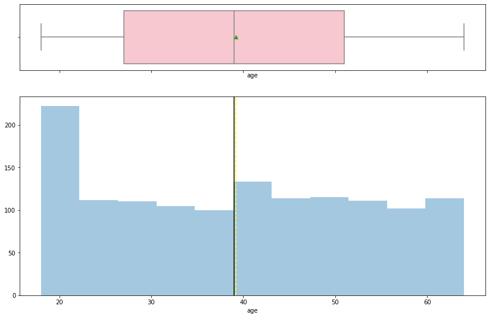

```python
histogram_boxplot(Axis_Ins["age"])
plt.savefig('Plot_age.png')
plt.show()
```

### Observation

```
1. There are no outliers
2. Age is uniformly distributed with Zero Skewness. Mean (39.2) and Median (39) are near equal as shown
3. 25% of the customers are 27 yrs of age while 75% of them are 51 years of age
```

### BMI Analysis

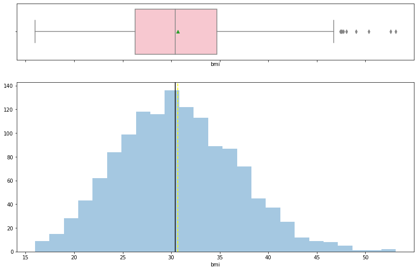

```python
histogram_boxplot(Axis_Ins["bmi"])
plt.savefig('Plot_bmi.png')
plt.show()
```

## Observation

1. There are significant outliers which triggered a form of minimal skewness.
2. The BMI Index is a normal distribution. Mean (30.6) is approx. equal to Median (30.4)
3. We can infer that the insurance company's customer distribution is fairly overweight
4. There is a presence of outliers which may indicate variability in data collection

### Children Analysis

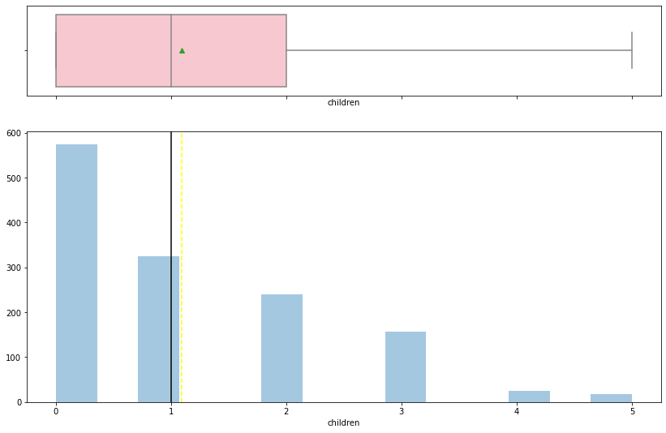

```python
histogram_boxplot(Axis_Ins["children"])
plt.savefig('Plot_chil.png')
plt.show()
```

### Charges Analysis

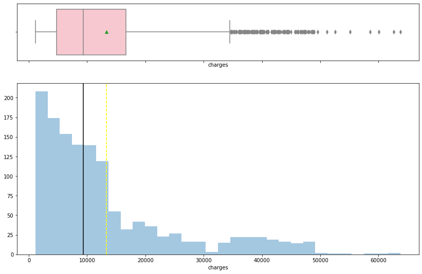

```python
histogram_boxplot(Axis_Ins["charges"])
plt.savefig('Plot_chg.png')
plt.show()
```

### Observation

1. The mean is greater than the median, hence the skewness to the right
2. There is a presence of a lot of outliers which greatly impacts on the mean position
3. 75% of the insurance medical claims is below of $16,640
4. There is an obvious possibility of error in the data gathering owing to the tremndous amount of outliers present

### Analysis of Categorical Variables

```python
# Function to create barplots that indicate percentage for each category.

def perc_on_bar(plot, feature):
    '''
    plot
    feature: categorical feature
    the function won't work if a column is passed in hue parameter
    '''
    total = len(feature) # length of the column
    for p in ax.patches:
        percentage = '{:.1f}%'.format(100 * p.get_height()/total) # percentage of each class of the category
        x = p.get_x() + p.get_width() / 2 - 0.05 # width of the plot
        y = p.get_y() + p.get_height()           # height of the plot
        ax.annotate(percentage, (x, y), size = 14) # annotate the percantage
    plt.show() # show the plot
```

### Sex Analysis

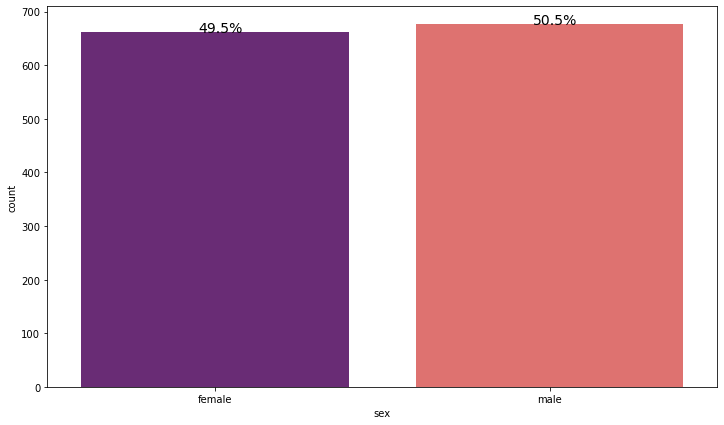

```python
plt.figure(figsize=(12,7))
ax = sns.countplot(Axis_Ins["sex"],palette='magma')
perc_on_bar(ax,Axis_Ins["sex"])
plt.savefig('Plot_sex.png')
```

### Observation

The Policy Holders are made up of Male( 50.5%) and Female(49.5%)

### Smoker Analysis

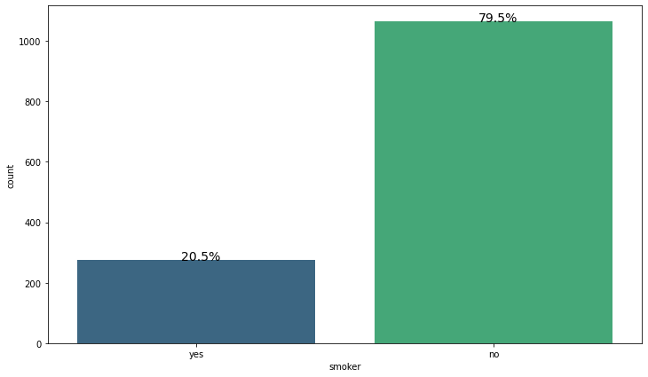

```python
plt.figure(figsize=(12,7))
ax = sns.countplot(Axis_Ins["smoker"],palette='viridis')
perc_on_bar(ax,Axis_Ins["smoker"])
plt.savefig('Plot_smk.png')
```

### Observation

The Insurance Policy Holders are made up of 20.5% Smokers and 79.5% Non-smokers.

### Region Analysis

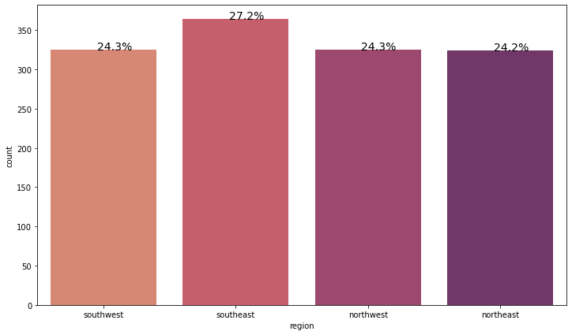

```python
plt.figure(figsize=(12,7))
ax = sns.countplot(Axis_Ins["region"],palette='flare')
perc_on_bar(ax,Axis_Ins["region"])
plt.savefig('Plot_reg.png')
```

### Observation

1. The Southeast has the highest percentage of Policy holders with 27.2%
2. The Southwest and Northwest pair come second with 24.3% of the policy holders respectively
3. The Northeast has the lowest percentage of policy holders at 24.2%

### BIVARIATE

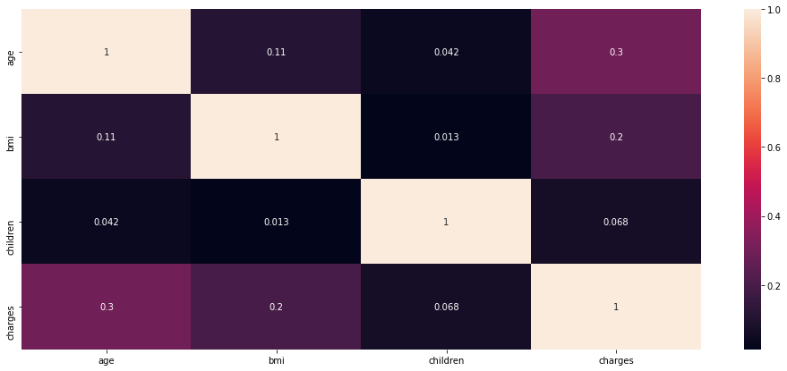

```python
plt.figure(figsize=(17,7))
sns.heatmap(Axis_Ins.corr(),annot=True) # Plotting a heatmap to determine the presence of relationships between variables
plt.savefig('plot_htmap.png')
plt.show()
```

### Observation

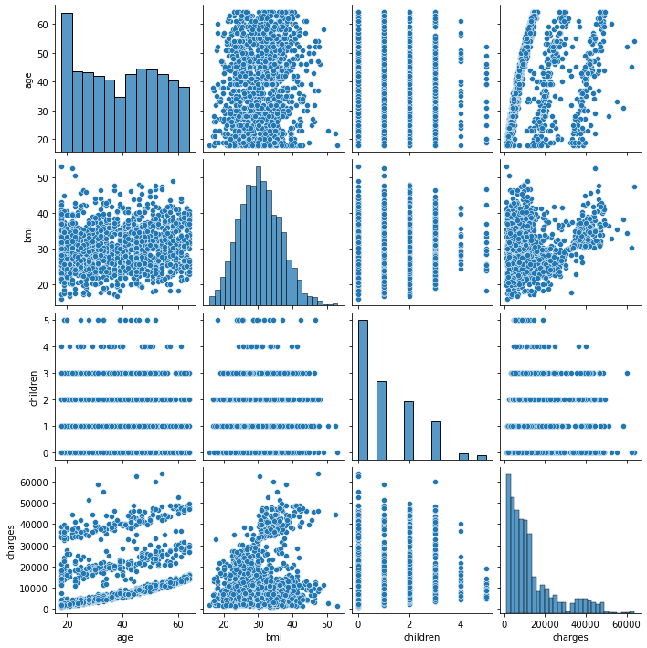

```python
sns.pairplot(Axis_Ins); # pair plot for all numerical variables
plt.savefig('Pair_plt.png')
plt.show()
```

### Observation

With an obvious lack of correlation per parity, there is a need to investigate further.

### Smoker Vs Age

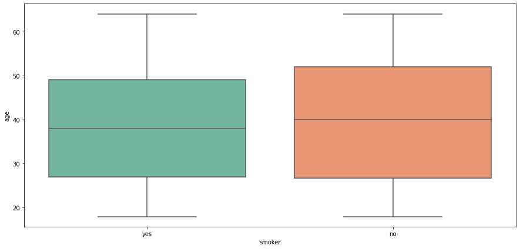

```python
plt.figure(figsize=(15,7))
sns.boxplot(Axis_Ins["smoker"],Axis_Ins["age"],palette="Set2") # plotting box plot
plt.savefig('Plot_SA.png')
plt.show()
```

### Observation

1. There are more smokers between ages 27-49yrs
2. There are more non-smokers in the !QR between 27 and 51 years of age
3. There are no outliers accross the smokers and non-smokers

### Smokers Vs BMI

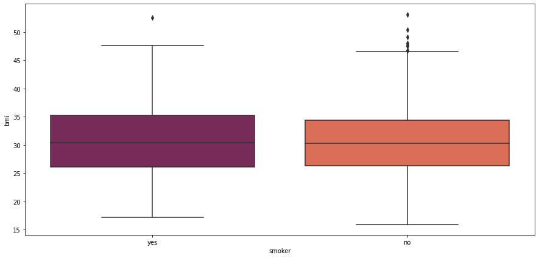

```python
plt.figure(figsize=(15,7))
sns.boxplot(Axis_Ins["smoker"],Axis_Ins["bmi"],palette="rocket")# Plotting Box plot
plt.savefig('Plot_SB.png')
plt.show()
```

### Observation

1. There are presence of outliers with a high BMI for smokers and more outliers for non-smokers respectively
2. It would appear as though the smokers have a higher BMI than the non-smokers in the IQR as can be deduced from the clusters
3. It is also interesting to note that the median BMI for both groups are equal to 30

### Smoke Vs Charges

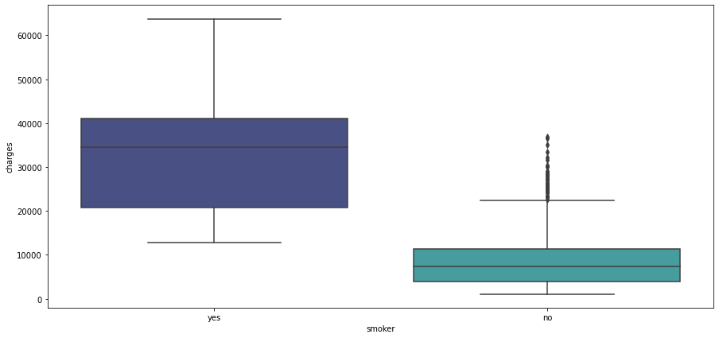

```python
plt.figure(figsize=(15,7))
sns.boxplot(Axis_Ins["smoker"],Axis_Ins["charges"],palette="mako")# Plotting a box plot
plt.savefig('Plot_SC.png')
plt.show()
```

### Smoker Vs Sex

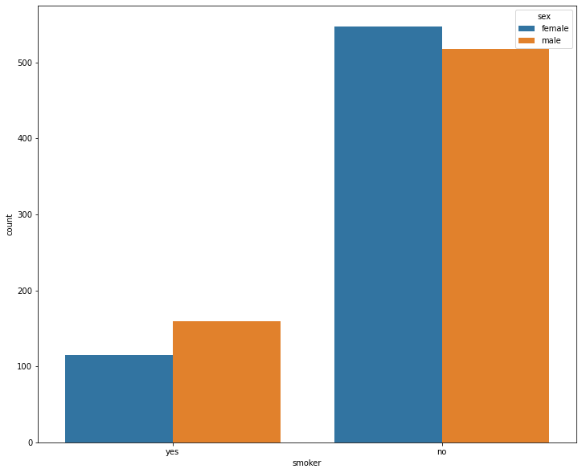

```python
plt.figure(figsize=(12,10)) # Count plot for the Bivariate analysis of 2 Cat.Variables
sns.countplot(Axis_Ins['smoker'],hue=Axis_Ins['sex'])
plt.savefig('countplt_SS.png')
plt.show()
```

### Observation

1. There are more female non-smokers (NS) than female smokers (S). Same is the case for Males
2. There are more Male non-smokers (NS) than there are male smokers

### Smokers Vs Regions

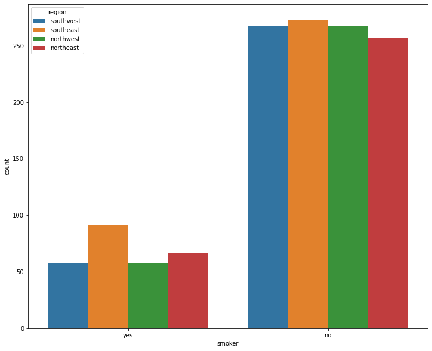

```python
plt.figure(figsize=(12,10)) # Bar plot for the Bivariate analysis of 2 Cat.Variables
sns.countplot(Axis_Ins['smoker'],hue=Axis_Ins['region'])
plt.savefig('countplt_SRE.png')
plt.show()
```

### Sex Vs Regions

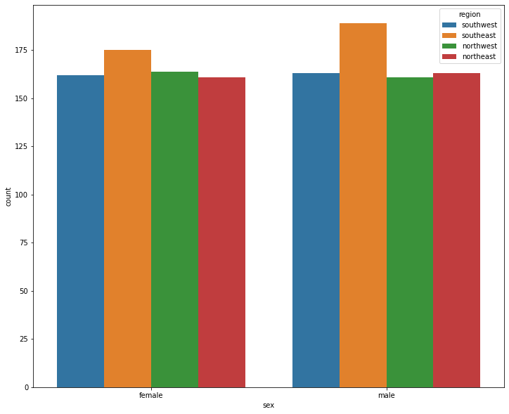

```python
plt.figure(figsize=(12,10)) # Bar plot for the Bivariate analysis of 2 Cat.Variables
sns.countplot(Axis_Ins['sex'],hue=Axis_Ins['region'])
plt.savefig('countplt_SR.png')
plt.show()
```

### Region Vs BMI

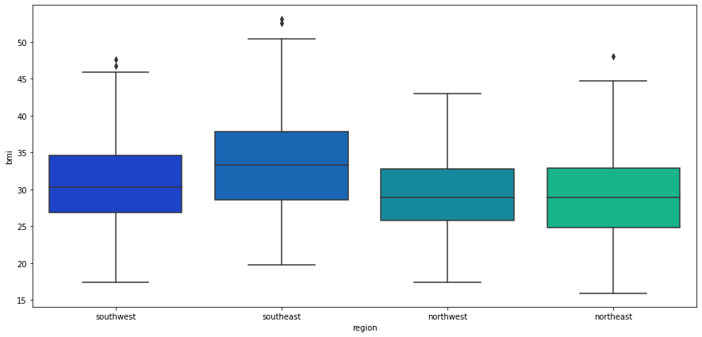

```python
plt.figure(figsize=(15,7))
sns.boxplot(Axis_Ins["region"],Axis_Ins["bmi"],palette="winter")
plt.savefig('Plot_RB.png')
plt.show()
```

### Observation

1. This plot validates the argument that the policy holders in the South East are more obese than the other regions.
2. The next to the Southeast is the Southwest and then the Northeast
3. Note also the presence of outliers in this regions

### Region Vs Charges

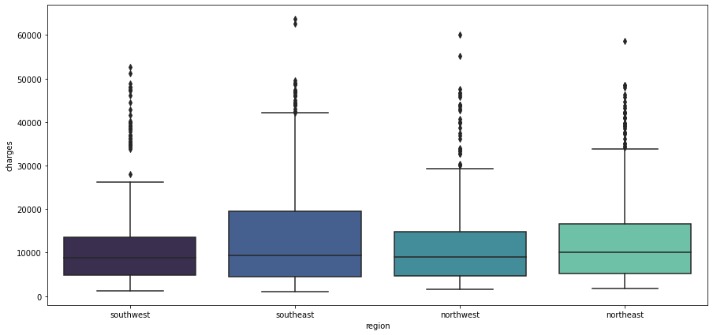

```python
plt.figure(figsize=(15,7))
sns.boxplot(Axis_Ins["region"],Axis_Ins["charges"],palette="mako")
plt.savefig('Plot_RC.png')
plt.show()
```

### Observation

1. The presence of outliers across all regions vs charges indicates a possible experimental error attributable to a wide variance
2. The South East returned the highest insurance medical costs followed by the North East and the the Northwest and finally the Southwest

### Sex Vs BMI

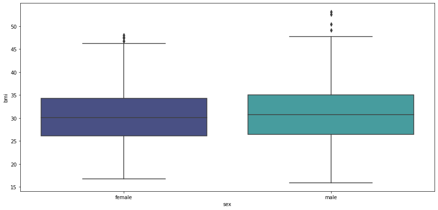

```python
plt.figure(figsize=(15,7))
sns.boxplot(Axis_Ins["sex"],Axis_Ins["bmi"],palette="mako")
plt.savefig('Plot_SxB.png')
plt.show()
```

### Observation

1. The males weigh heavier than the females but not by a huge gap
2. Both have outliers present

### Sex Vs Children

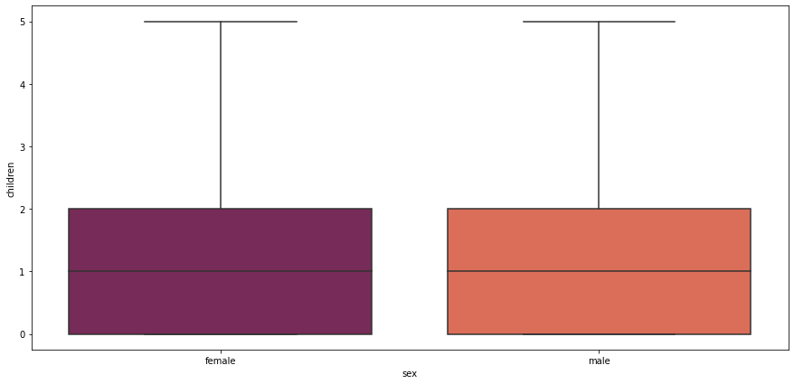

```python
plt.figure(figsize=(15,7))
sns.boxplot(Axis_Ins["sex"],Axis_Ins["children"],palette="rocket")
plt.savefig('Plot_Sch.png')
plt.show()
```

### Observation

Both Male and female policy holders seem to have an equal number of dependants

### BMI Vs Sex vs Children

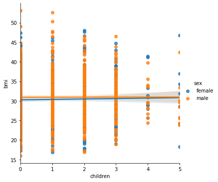

```python
sns.lmplot(y="bmi", x="children",hue="sex", data=Axis_Ins); # plotting a linear regression model
plt.savefig('Plt_lm.png')
plt.show()
```

### Observation

1. From the Linear regression plot, we can see only 4 females have a high BmI and Zero dependants
2. There are more males with dependents than there are females

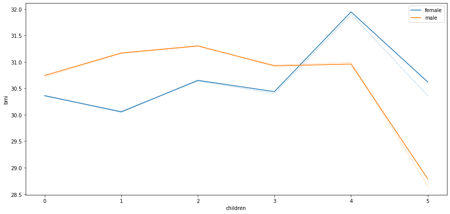

```python
plt.figure(figsize=(15,7))
sns.lineplot(Axis_Ins["children"],Axis_Ins["bmi"],hue=Axis_Ins["sex"],ci=0)
plt.legend(bbox_to_anchor=(1.00, 1))
plt.savefig('lineplt.png')
plt.show()
```

### Observation

1. The above validates the opinion that males with BMI (30.6-31.3) have 2 dependents or less and those with BMI of 30.8 and below have 3 or more dependants
2. Overall, females with lesser BMIs compared to males maintain 2 dependents or less as well but have 3 or more dependents as their BMIs spiked upwards from 30.5

### Grouping data w.r.t to categorical variables to build Policy Holder profiles

### Sex

```python
Axis_Ins[Axis_Ins["sex"]=="female"].describe(include="all")# deriving the statistics for the female policy holders
```

|  | age | sex | bmi | children | smoker | region | charges |
| --- | --- | --- | --- | --- | --- | --- | --- |
| count | 662.000000 | 662 | 662.000000 | 662.000000 | 662 | 662 | 662.000000 |
| unique | NaN | 1 | NaN | NaN | 2 | 4 | NaN |
| top | NaN | female | NaN | NaN | no | southeast | NaN |
| freq | NaN | 662 | NaN | NaN | 547 | 175 | NaN |
| mean | 39.503021 | NaN | 30.377749 | 1.074018 | NaN | NaN | 12569.578844 |
| std | 14.054223 | NaN | 6.046023 | 1.192115 | NaN | NaN | 11128.703801 |
| min | 18.000000 | NaN | 16.815000 | 0.000000 | NaN | NaN | 1607.510100 |
| 25% | 27.000000 | NaN | 26.125000 | 0.000000 | NaN | NaN | 4885.158700 |
| 50% | 40.000000 | NaN | 30.107500 | 1.000000 | NaN | NaN | 9412.962500 |
| 75% | 51.750000 | NaN | 34.313750 | 2.000000 | NaN | NaN | 14454.691825 |
| max | 64.000000 | NaN | 48.070000 | 5.000000 | NaN | NaN | 63770.428010 |

### Observation

1. There are 662 females with a mean age of approx. 40yrs with the SouthEast region having the highest population of females with 175
2. Most female Policy holders are between the ages of 27 and 52 or late 20s and early 50s
3. Most of them have their BMIs reading between 26kg to 34kg. the females are grossly overweight
4. Majority of the females have at most 2 dependents (0-2)per policy
5. There are 547 non-smoking females
6. The medical insurance claims posted by most females is predominantly from roughly 4900 and 14,500

```python
Axis_Ins[Axis_Ins["sex"]=="male"].describe(include="all")# deriving the statistics for the male policy holders
```

|  | age | sex | bmi | children | smoker | region | charges |
| --- | --- | --- | --- | --- | --- | --- | --- |
| count | 676.000000 | 676 | 676.000000 | 676.000000 | 676 | 676 | 676.000000 |
| unique | NaN | 1 | NaN | NaN | 2 | 4 | NaN |
| top | NaN | male | NaN | NaN | no | southeast | NaN |
| freq | NaN | 676 | NaN | NaN | 517 | 189 | NaN |
| mean | 38.917160 | NaN | 30.943129 | 1.115385 | NaN | NaN | 13956.751178 |
| std | 14.050141 | NaN | 6.140435 | 1.218986 | NaN | NaN | 12971.025915 |
| min | 18.000000 | NaN | 15.960000 | 0.000000 | NaN | NaN | 1121.873900 |
| 25% | 26.000000 | NaN | 26.410000 | 0.000000 | NaN | NaN | 4619.134000 |
| 50% | 39.000000 | NaN | 30.687500 | 1.000000 | NaN | NaN | 9369.615750 |
| 75% | 51.000000 | NaN | 34.992500 | 2.000000 | NaN | NaN | 18989.590250 |
| max | 64.000000 | NaN | 53.130000 | 5.000000 | NaN | NaN | 62592.873090 |

### Observation

1. There are 676 males with a mean age of approx. 39yrs with the SouthEast region having the most males with 189
2. Most Male Policy holders are between the ages of 26 and 51 or mid-20s and early 50s
3. Most of them have their BMIs reading between 26kg to 35kg
4. Majority of the males have at most 2 dependents (0-2) per plicy
5. There are 517 non-smoking males
6. The medical insurance claims posted by most males ranges predominantly from 4600 and 19,000 approx.

### Smoker

```python
Axis_Ins[Axis_Ins["smoker"]=="yes"].describe(include="all")# deriving the statistics for the smoking policy holders
```

|  | age | sex | bmi | children | smoker | region | charges |
| --- | --- | --- | --- | --- | --- | --- | --- |
| count | 274.000000 | 274 | 274.000000 | 274.000000 | 274 | 274 | 274.000000 |
| unique | NaN | 2 | NaN | NaN | 1 | 4 | NaN |
| top | NaN | male | NaN | NaN | yes | southeast | NaN |
| freq | NaN | 159 | NaN | NaN | 274 | 91 | NaN |
| mean | 38.514599 | NaN | 30.708449 | 1.113139 | NaN | NaN | 32050.231832 |
| std | 13.923186 | NaN | 6.318644 | 1.157066 | NaN | NaN | 11541.547176 |
| min | 18.000000 | NaN | 17.195000 | 0.000000 | NaN | NaN | 12829.455100 |
| 25% | 27.000000 | NaN | 26.083750 | 0.000000 | NaN | NaN | 20826.244213 |
| 50% | 38.000000 | NaN | 30.447500 | 1.000000 | NaN | NaN | 34456.348450 |
| 75% | 49.000000 | NaN | 35.200000 | 2.000000 | NaN | NaN | 41019.207275 |
| max | 64.000000 | NaN | 52.580000 | 5.000000 | NaN | NaN | 63770.428010 |

```python
Axis_Ins[Axis_Ins["smoker"]=="no"].describe(include="all")# deriving the statistics for the non-smoking policy holders
```

|  | age | sex | bmi | children | smoker | region | charges |
| --- | --- | --- | --- | --- | --- | --- | --- |
| count | 1064.000000 | 1064 | 1064.000000 | 1064.000000 | 1064 | 1064 | 1064.000000 |
| unique | NaN | 2 | NaN | NaN | 1 | 4 | NaN |
| top | NaN | female | NaN | NaN | no | southeast | NaN |
| freq | NaN | 547 | NaN | NaN | 1064 | 273 | NaN |
| mean | 39.385338 | NaN | 30.651795 | 1.090226 | NaN | NaN | 8434.268298 |
| std | 14.083410 | NaN | 6.043111 | 1.218136 | NaN | NaN | 5993.781819 |
| min | 18.000000 | NaN | 15.960000 | 0.000000 | NaN | NaN | 1121.873900 |
| 25% | 26.750000 | NaN | 26.315000 | 0.000000 | NaN | NaN | 3986.438700 |
| 50% | 40.000000 | NaN | 30.352500 | 1.000000 | NaN | NaN | 7345.405300 |
| 75% | 52.000000 | NaN | 34.430000 | 2.000000 | NaN | NaN | 11362.887050 |
| max | 64.000000 | NaN | 53.130000 | 5.000000 | NaN | NaN | 36910.608030 |

### Region

```python
Axis_Ins[Axis_Ins["region"]=="southeast"].describe(include="all")# deriving the statistics for policy holders by region
```

|  | age | sex | bmi | children | smoker | region | charges |
| --- | --- | --- | --- | --- | --- | --- | --- |
| count | 364.000000 | 364 | 364.000000 | 364.000000 | 364 | 364 | 364.000000 |
| unique | NaN | 2 | NaN | NaN | 2 | 1 | NaN |
| top | NaN | male | NaN | NaN | no | southeast | NaN |
| freq | NaN | 189 | NaN | NaN | 273 | 364 | NaN |
| mean | 38.939560 | NaN | 33.355989 | 1.049451 | NaN | NaN | 14735.411438 |
| std | 14.164585 | NaN | 6.477648 | 1.177276 | NaN | NaN | 13971.098589 |
| min | 18.000000 | NaN | 19.800000 | 0.000000 | NaN | NaN | 1121.873900 |
| 25% | 26.750000 | NaN | 28.572500 | 0.000000 | NaN | NaN | 4440.886200 |
| 50% | 39.000000 | NaN | 33.330000 | 1.000000 | NaN | NaN | 9294.131950 |
| 75% | 51.000000 | NaN | 37.812500 | 2.000000 | NaN | NaN | 19526.286900 |
| max | 64.000000 | NaN | 53.130000 | 5.000000 | NaN | NaN | 63770.428010 |

```python
Axis_Ins[Axis_Ins["region"]=="northeast"].describe(include="all")# deriving the statistics for policy holders by region
```

|  | age | sex | bmi | children | smoker | region | charges |
| --- | --- | --- | --- | --- | --- | --- | --- |
| count | 324.000000 | 324 | 324.000000 | 324.000000 | 324 | 324 | 324.000000 |
| unique | NaN | 2 | NaN | NaN | 2 | 1 | NaN |
| top | NaN | male | NaN | NaN | no | northeast | NaN |
| freq | NaN | 163 | NaN | NaN | 257 | 324 | NaN |
| mean | 39.268519 | NaN | 29.173503 | 1.046296 | NaN | NaN | 13406.384516 |
| std | 14.069007 | NaN | 5.937513 | 1.198949 | NaN | NaN | 11255.803066 |
| min | 18.000000 | NaN | 15.960000 | 0.000000 | NaN | NaN | 1694.796400 |
| 25% | 27.000000 | NaN | 24.866250 | 0.000000 | NaN | NaN | 5194.322288 |
| 50% | 39.500000 | NaN | 28.880000 | 1.000000 | NaN | NaN | 10057.652025 |
| 75% | 51.000000 | NaN | 32.893750 | 2.000000 | NaN | NaN | 16687.364100 |
| max | 64.000000 | NaN | 48.070000 | 5.000000 | NaN | NaN | 58571.074480 |

```python
Axis_Ins[Axis_Ins["region"]=="southwest"].describe(include="all")# deriving the statistics for policy holders by region
```

|  | age | sex | bmi | children | smoker | region | charges |
| --- | --- | --- | --- | --- | --- | --- | --- |
| count | 325.000000 | 325 | 325.000000 | 325.000000 | 325 | 325 | 325.000000 |
| unique | NaN | 2 | NaN | NaN | 2 | 1 | NaN |
| top | NaN | male | NaN | NaN | no | southwest | NaN |
| freq | NaN | 163 | NaN | NaN | 267 | 325 | NaN |
| mean | 39.455385 | NaN | 30.596615 | 1.141538 | NaN | NaN | 12346.937377 |
| std | 13.959886 | NaN | 5.691836 | 1.275952 | NaN | NaN | 11557.179101 |
| min | 19.000000 | NaN | 17.400000 | 0.000000 | NaN | NaN | 1241.565000 |
| 25% | 27.000000 | NaN | 26.900000 | 0.000000 | NaN | NaN | 4751.070000 |
| 50% | 39.000000 | NaN | 30.300000 | 1.000000 | NaN | NaN | 8798.593000 |
| 75% | 51.000000 | NaN | 34.600000 | 2.000000 | NaN | NaN | 13462.520000 |
| max | 64.000000 | NaN | 47.600000 | 5.000000 | NaN | NaN | 52590.829390 |

### Observation

```python
Axis_Ins[Axis_Ins["region"]=="northwest"].describe(include="all")# deriving the statistics for policy holders by region
```

|  | age | sex | bmi | children | smoker | region | charges |
| --- | --- | --- | --- | --- | --- | --- | --- |
| count | 325.000000 | 325 | 325.000000 | 325.000000 | 325 | 325 | 325.000000 |
| unique | NaN | 2 | NaN | NaN | 2 | 1 | NaN |
| top | NaN | female | NaN | NaN | no | northwest | NaN |
| freq | NaN | 164 | NaN | NaN | 267 | 325 | NaN |
| mean | 39.196923 | NaN | 29.199785 | 1.147692 | NaN | NaN | 12417.575374 |
| std | 14.051646 | NaN | 5.136765 | 1.171828 | NaN | NaN | 11072.276928 |
| min | 19.000000 | NaN | 17.385000 | 0.000000 | NaN | NaN | 1621.340200 |
| 25% | 26.000000 | NaN | 25.745000 | 0.000000 | NaN | NaN | 4719.736550 |
| 50% | 39.000000 | NaN | 28.880000 | 1.000000 | NaN | NaN | 8965.795750 |
| 75% | 51.000000 | NaN | 32.775000 | 2.000000 | NaN | NaN | 14711.743800 |
| max | 64.000000 | NaN | 42.940000 | 5.000000 | NaN | NaN | 60021.398970 |

## Hypothesis Testing

### Question 2 : To test the null hypothesis that the claims by people who smoke is greater than those who don't

#### Hypothesis formulation

Let's write the null and alternative hypothesis

Let μ1,μ2

be the mean medical claim for smokers and non-smokers respectively.

We will test the null hypothesis

```
H0:μ1=μ2
```

against the alternate hypothesis

```
Ha:μ1>μ2
```

#### Preparing the Data

```python
smoking_data = Axis_Ins[Axis_Ins["smoker"]=="yes"]# data for smoking policy holders
smoking_data
```

|  | age | sex | bmi | children | smoker | region | charges |
| --- | --- | --- | --- | --- | --- | --- | --- |
| 0 | 19 | female | 27.900 | 0 | yes | southwest | 16884.92400 |
| 11 | 62 | female | 26.290 | 0 | yes | southeast | 27808.72510 |
| 14 | 27 | male | 42.130 | 0 | yes | southeast | 39611.75770 |
| 19 | 30 | male | 35.300 | 0 | yes | southwest | 36837.46700 |
| 23 | 34 | female | 31.920 | 1 | yes | northeast | 37701.87680 |
| ... | ... | ... | ... | ... | ... | ... | ... |
| 1313 | 19 | female | 34.700 | 2 | yes | southwest | 36397.57600 |
| 1314 | 30 | female | 23.655 | 3 | yes | northwest | 18765.87545 |
| 1321 | 62 | male | 26.695 | 0 | yes | northeast | 28101.33305 |
| 1323 | 42 | female | 40.370 | 2 | yes | southeast | 43896.37630 |
| 1337 | 61 | female | 29.070 | 0 | yes | northwest | 29141.36030 |

274 rows × 7 columns

```python
non_smoking_data= Axis_Ins[Axis_Ins["smoker"]=="no"]# data for non-smoking policy holders
non_smoking_data
```

|  | age | sex | bmi | children | smoker | region | charges |
| --- | --- | --- | --- | --- | --- | --- | --- |
| 1 | 18 | male | 33.770 | 1 | no | southeast | 1725.55230 |
| 2 | 28 | male | 33.000 | 3 | no | southeast | 4449.46200 |
| 3 | 33 | male | 22.705 | 0 | no | northwest | 21984.47061 |
| 4 | 32 | male | 28.880 | 0 | no | northwest | 3866.85520 |
| 5 | 31 | female | 25.740 | 0 | no | southeast | 3756.62160 |
| ... | ... | ... | ... | ... | ... | ... | ... |
| 1332 | 52 | female | 44.700 | 3 | no | southwest | 11411.68500 |
| 1333 | 50 | male | 30.970 | 3 | no | northwest | 10600.54830 |
| 1334 | 18 | female | 31.920 | 0 | no | northeast | 2205.98080 |
| 1335 | 18 | female | 36.850 | 0 | no | southeast | 1629.83350 |
| 1336 | 21 | female | 25.800 | 0 | no | southwest | 2007.94500 |

1064 rows × 7 columns

```python
print ('The mean of the medical claims of the smoking population is', smoking_data.charges.mean())
print ('The mean of the medical claims of the non-smoking population is', non_smoking_data.charges.mean())
print ('The standard deviation of the medical claims of the smoking population is', smoking_data.charges.std())
print ('The standard deviation of the medical claims of the non-smoking population is', non_smoking_data.charges.std())
```

```
The mean of the medical claims of the smoking population is 32050.23183153285
The mean of the medical claims of the non-smoking population is 8434.268297856199
The standard deviation of the medical claims of the smoking population is 11541.547175589121
The standard deviation of the medical claims of the non-smoking population is 5993.781819194933
```

### Testing to confirm if the following assumptions establishes the application of a T-test for Hypothesis

1. Continuous data - Yes, the medical claim is measured on a continuous scale.
2. Normally distributed populations - Yes, we are informed that the populations are assumed to be normal.
3. Independent populations - As we are taking random samples for two different groups, the two samples are from two independent populations.
4. Unequal population standard deviations - As the sample standard deviations are different, the population standard deviations may be assumed to be different.
5. Random sampling from the population - Yes, we are informed that the collected sample a simple random sample.

#### Observation

This is a one-tailed t-test for Two Independent Samples with un-equal standard deviations

```python
#import the required functions
from scipy.stats import ttest_ind

# find the p-value
test_stat, p_value = ttest_ind(smoking_data['charges'], non_smoking_data['charges'].dropna(), equal_var = False, alternative = 'greater')
print('The test statistics is',test_stat)
print('The p-value is', p_value)
```

```
The test statistics is 32.751887766341824
The p-value is 2.94473222335849e-103
```

### Insight

As the p-value is far less than the level of significance, we can reject the null hypothesis. Hence, we have enough statistical evidence to prove that the medical claims of smokers have a higher mean value than that of the non-smokers at 0.05 significance level

### Question 3 : To test the null hypothesis that the BMI of females is different from that of males

#### Hypothesis formulation

Let's write the null and alternative hypothesis

Let μ1,μ2 be the mean BMI for the male and female policy holders respectively.

We will test the null hypothesis

```
H0:μ1=μ2
```

against the alternate hypothesis

```
Ha:μ1≠μ2
```

#### Preparing the Data

```python
male_dat= Axis_Ins[Axis_Ins["sex"]=="male"]# data for male policy holders
male_dat
```

|  | age | sex | bmi | children | smoker | region | charges |
| --- | --- | --- | --- | --- | --- | --- | --- |
| 1 | 18 | male | 33.770 | 1 | no | southeast | 1725.55230 |
| 2 | 28 | male | 33.000 | 3 | no | southeast | 4449.46200 |
| 3 | 33 | male | 22.705 | 0 | no | northwest | 21984.47061 |
| 4 | 32 | male | 28.880 | 0 | no | northwest | 3866.85520 |
| 8 | 37 | male | 29.830 | 2 | no | northeast | 6406.41070 |
| ... | ... | ... | ... | ... | ... | ... | ... |
| 1324 | 31 | male | 25.935 | 1 | no | northwest | 4239.89265 |
| 1325 | 61 | male | 33.535 | 0 | no | northeast | 13143.33665 |
| 1327 | 51 | male | 30.030 | 1 | no | southeast | 9377.90470 |
| 1329 | 52 | male | 38.600 | 2 | no | southwest | 10325.20600 |
| 1333 | 50 | male | 30.970 | 3 | no | northwest | 10600.54830 |

676 rows × 7 columns

```python
female_dat= Axis_Ins[Axis_Ins["sex"]=="female"]# data for female policy holders
female_dat
```

|  | age | sex | bmi | children | smoker | region | charges |
| --- | --- | --- | --- | --- | --- | --- | --- |
| 0 | 19 | female | 27.90 | 0 | yes | southwest | 16884.92400 |
| 5 | 31 | female | 25.74 | 0 | no | southeast | 3756.62160 |
| 6 | 46 | female | 33.44 | 1 | no | southeast | 8240.58960 |
| 7 | 37 | female | 27.74 | 3 | no | northwest | 7281.50560 |
| 9 | 60 | female | 25.84 | 0 | no | northwest | 28923.13692 |
| ... | ... | ... | ... | ... | ... | ... | ... |
| 1332 | 52 | female | 44.70 | 3 | no | southwest | 11411.68500 |
| 1334 | 18 | female | 31.92 | 0 | no | northeast | 2205.98080 |
| 1335 | 18 | female | 36.85 | 0 | no | southeast | 1629.83350 |
| 1336 | 21 | female | 25.80 | 0 | no | southwest | 2007.94500 |
| 1337 | 61 | female | 29.07 | 0 | yes | northwest | 29141.36030 |

662 rows × 7 columns

```python
print ('The mean of the bmi for males is', male_dat.bmi.mean())
print ('The mean of the bmi for females is', female_dat.bmi.mean())
print ('The standard deviation of the of the bmi for males is',male_dat.bmi.std())
print ('The standard deviation of the bmi for females is', female_dat.bmi.std())
```

```
The mean of the bmi for males is 30.943128698224832
The mean of the bmi for females is 30.377749244713023
The standard deviation of the of the bmi for males is 6.140434615792248
The standard deviation of the bmi for females is 6.046023085745338
```

### Testing to confirm if the following assumptions establishes the application of a T-test for Hypothesis

1. Continuous data - Yes, the body mass index (bmi) is measured on a continuous scale.
2. Normally distributed populations - Yes, we are informed that the populations are assumed to be normal.
3. Independent populations - As we are taking random samples for two different groups, the two samples are from two independent populations.
4. Equal population standard deviations - As the sample standard deviations are equal, the population standard deviations may be assumed to be equal.
5. Random sampling from the population - Yes, we are informed that the collected sample a simple random sample.

### Observation

This is a two-tailed t-test for Two Independent Samples with equal standard deviations

```python
#import the required functions
from scipy.stats import ttest_ind

# find the p-value
test_stat, p_value = ttest_ind(male_dat['bmi'], female_dat['bmi'], equal_var = True, alternative = 'two-sided')
print('The test statistics is ' + str(test_stat))
print('The p-value is ' + str(p_value))
```

```
The test statistics is 1.696752635752224
The p-value is 0.08997637178984932
```

### Insight

As the p-value is greater than the level of significance of 0.05, we fail to reject the null hypothesis. Hence, we do not have enough statistical evidence to prove that there is any difference between the mean bmi values of males and females at 0.05 significance level

### Question 4 : To validate if the proportion of smokers is significantly different across the four regions

#### Hypothesis formulation

Let's write the null and alternative hypothesis

We will test the null hypothesis

```
H0:

Proportion of smokers does not vary significantly accross regions.
```

against the alternate hypothesis

```
Ha:

Proportion of smokers vary significantly accross regions.
```

Let's test whether the assumptions are satisfied or not

1. Categorical variables - Yes
2. Expected value of the number of sample observations in each level of the variable is at least 5 - Yes, the number of observations in each level is greater than 5.
3. Random sampling from the population - Yes, we are informed that the collected sample is a simple random sample.

#### Observation

This is a Chi Square Test for Independence

#### Preparing the Data

```python
cont_table= pd.crosstab(Axis_Ins.region,Axis_Ins.smoker) # function to generate contingency table
cont_table
```

| smoker region | no | yes |
| --- | --- | --- |
| northeast | 257 | 67 |
| northwest | 267 | 58 |
| southeast | 273 | 91 |
| southwest | 267 | 58 |

```python
# import the required function
from scipy.stats import chi2_contingency

# find the p-value
chi, p_value, dof, expected = stats.chi2_contingency(cont_table, correction=True, lambda_=None)
print('The p-value is', p_value)
```

```
The p-value is 0.06171954839170541
```

### Insight

As the p-value is greater than the level of significance, we fail to reject the null hypothesis. Hence, we do not have enough statistical evidence to prove that there is a significant difference in the proportion of smokers accross the regions at 0.05 significance level

### Question 5 : To test the hypothesis if the mean BMI of women with 0,1 and 2 children respectively are different

#### Hypothesis formulation

Let μ1,μ2,μ3

be the means of BMI of women with 0, 1 and 2 children respectively.

We will test the null hypothesis

```
H0:μ1=μ2=μ3
```

against the alternative hypothesis

```
Ha:
```

At least one mean BMI is different from the rest.

#### Preparing the Data

```python
female_dat
```

|  | age | sex | bmi | children | smoker | region | charges |
| --- | --- | --- | --- | --- | --- | --- | --- |
| 0 | 19 | female | 27.90 | 0 | yes | southwest | 16884.92400 |
| 5 | 31 | female | 25.74 | 0 | no | southeast | 3756.62160 |
| 6 | 46 | female | 33.44 | 1 | no | southeast | 8240.58960 |
| 7 | 37 | female | 27.74 | 3 | no | northwest | 7281.50560 |
| 9 | 60 | female | 25.84 | 0 | no | northwest | 28923.13692 |
| ... | ... | ... | ... | ... | ... | ... | ... |
| 1332 | 52 | female | 44.70 | 3 | no | southwest | 11411.68500 |
| 1334 | 18 | female | 31.92 | 0 | no | northeast | 2205.98080 |
| 1335 | 18 | female | 36.85 | 0 | no | southeast | 1629.83350 |
| 1336 | 21 | female | 25.80 | 0 | no | southwest | 2007.94500 |
| 1337 | 61 | female | 29.07 | 0 | yes | northwest | 29141.36030 |

662 rows × 7 columns

```python
female_dat.dtypes
```

[output not shown]

```python
aov_data = female_dat [female_dat['children']<3].reset_index(drop=True) # creating a dataset for statiscal analysis and hypothesis test using ANOVA
aov_data
```

|  | age | sex | bmi | children | smoker | region | charges |
| --- | --- | --- | --- | --- | --- | --- | --- |
| 0 | 19 | female | 27.90 | 0 | yes | southwest | 16884.92400 |
| 1 | 31 | female | 25.74 | 0 | no | southeast | 3756.62160 |
| 2 | 46 | female | 33.44 | 1 | no | southeast | 8240.58960 |
| 3 | 60 | female | 25.84 | 0 | no | northwest | 28923.13692 |
| 4 | 62 | female | 26.29 | 0 | yes | southeast | 27808.72510 |
| ... | ... | ... | ... | ... | ... | ... | ... |
| 561 | 23 | female | 33.40 | 0 | no | southwest | 10795.93733 |
| 562 | 18 | female | 31.92 | 0 | no | northeast | 2205.98080 |
| 563 | 18 | female | 36.85 | 0 | no | southeast | 1629.83350 |
| 564 | 21 | female | 25.80 | 0 | no | southwest | 2007.94500 |
| 565 | 61 | female | 29.07 | 0 | yes | northwest | 29141.36030 |

566 rows × 7 columns

```python
aov_data.dtypes
```

[output not shown]

```python
aov_data['children'].value_counts()# this shows the frequecy of dependants(children) per group of women
```

```
0    289
1    158
2    119
Name: children, dtype: int64
```

```
children
0    30.361522
1    30.052658
2    30.649790
Name: bmi, dtype: float64
```

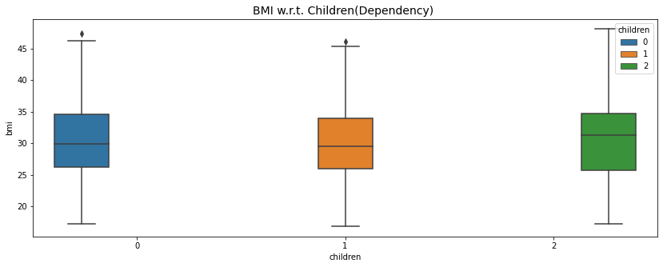

```python
# mean of bmi of different women groups at different levels dependency(dependants)
print(aov_data.groupby("children")["bmi"].mean())

# draw the boxplot for visualization
fig, ax = plt.subplots(figsize = (14,5))
a = sns.boxplot(x= "children", y = 'bmi' , data = aov_data, hue = 'children')
a.set_title("BMI w.r.t. Children(Dependency) ", fontsize=14)
plt.savefig('Plt_aov.png')
plt.show()
```

#### Testing for Normality and Equality of Variance Assumptions

```
For testing of normality, Shapiro-Wilk’s test is applied to the response variable.
For equality of varaince, Levene test is applied to the response variable.
```

### Shapiro-Wilk’s test

```
We will test the null hypothesis

H0:  Body Mass Index follows a normal distribution against

     against the alternative hypothesis

Ha:  Body Mass Index does not follow a normal distribution
```

```python
# Assumption 1: Normality
# import the required function
from scipy import stats

# find the p-value
w, p_value = stats.shapiro(aov_data['bmi'])
print('The p-value is', p_value)
```

```
The p-value is 0.010864038951694965
```

### Insight

The p-value is less than the level of significance,hence we have enough statistical evidence to show that the body mass index does not follow a normal distribution at a 0.05 significance level.

#### Observation: This is a One-Way ANOVA test which violates the normality assumption.

### Levene’s test

We will test the null hypothesis

```
    H0    : All the population variances are equal
```

against the alternative hypothesis

```
    Ha    : At least one variance is different from the rest
```

```python
#Assumption 2: Homogeneity of Variance
#import the required function
from scipy.stats import levene
statistic, p_value = levene(aov_data['bmi'][aov_data['children']==0],
                            aov_data['bmi'][aov_data['children']==1],
                            aov_data['bmi'][aov_data['children']==2])

# find the p-value
print('The p-value is', p_value)
```

```
The p-value is 0.3899432394522804
```

### Insight

As the p-value is much greater than the level of significance, we fail to reject the null hypothesis of homogeneity of variances. Hence, we do not have enough statistical evidence to prove that at least one variance is different from the rest at 0.05 significance level.

#### Let's test whether the assumptions are satisfied or not

1. The populations are normally distributed - No, the normality assumption was violated as seen using the Shapiro-Wilk’s test.
2. Samples are independent simple random samples - Yes, we are informed that the collected sample is a simple random sample.
3. Population variances are equal - Yes, the homogeneity of variance assumption is verified using the Levene's test.

### Let's find the p-value

```python
#import the required function
from scipy.stats import f_oneway

# perform one-way anova test
test_stat, p_value = f_oneway(aov_data.loc[aov_data['children'] == 0, 'bmi'],
                              aov_data.loc[aov_data['children'] == 1, 'bmi'],
                              aov_data.loc[aov_data['children'] == 2, 'bmi'])
print('The p-value is ' + str(p_value))
```

```
The p-value is 0.7158579926754841
```

Insight

As the p-value is much greater than the level of significance, we fail to reject the null hypothesis of equality of means. Hence, we do not have enough statistical evidence to prove that at least one mean variance is different from the rest at 0.05 significance level.